# notebook15dc3223e4

## 4.7. Model LSTM Profund amb Optimització d'Hiperparàmetres utilitzant Optuna

Construir un model LSTM més profund (amb més capes) i utilitzar Optuna per optimitzar hiperparàmetres clau. A continuació, comparar el seu rendiment amb els models anteriors (RNN, GRU i LSTM bàsic)

**Exercici [1.75 pts.]:** Definició del Model LSTM Profund. Crearem un model amb:

- 2 capes LSTM (amb return_sequences=True a la primera per apilar-les).
- Capa Densa final.
- Dropout per a regularització (evitar overfitting).

Després toca definir hiperparàmetres a Optimitzar amb Optuna. Optuna buscarà la millor combinació de:

- Nombre de neurones a cada capa LSTM: Entre 32 i 128.
- Taxa de Dropout: Entre 0.1 i 0.5.
- Taxa d'aprenentatge (learning rate): Entre 1e-4 i 1e-2 (log scale).
- Batch size: 32, 64 o 128.

Finalment, avalua i compara amb els models anteriors. Per fer-ho et proporcionem el codi per a una millor llegibilitat.

```python
!pip install optuna # Recorda instal·lar en cas de no tenir-lo
```

```python
# Completa l'exercici
def create_sequences(data, window_size):
    sequences = []
    labels = []
    for i in range(len(data) - window_size):
        seq = data[i:i + window_size]
        lab = data[i + window_size]
        sequences.append(seq)
        labels.append(lab)
    return np.array(sequences), np.array(labels)

window_size = 24
X, y = create_sequences(scaled_df.values, window_size)

X_train, X_test, y_train, y_test = train_test_split(X, y, test_size=0.2, shuffle=False)

import optuna
from tensorflow.keras.layers import Dropout, LSTM, Dense
from tensorflow.keras.optimizers import Adam
callback = EarlyStopping(monitor='val_loss', patience=10)
# Model optuna
def objective(trial):
    units = trial.suggest_int("units", 32, 128)
    dropout_rate = trial.suggest_float("dropout_rate", 0.1, 0.5)
    learning_rate = trial.suggest_float("learning_rate", 1e-4, 1e-2, log=True)
    batch_size = trial.suggest_categorical("batch_size", [32, 64, 128])

    model_deep_lstm = Sequential()
    model_deep_lstm.add(LSTM(units, return_sequences=True, input_shape=(window_size, 1)))
    model_deep_lstm.add(LSTM(units))
    model_deep_lstm.add(Dropout(dropout_rate))
    model_deep_lstm.add(Dense(1))

    model_deep_lstm.compile(optimizer=Adam(learning_rate=learning_rate), loss='mean_squared_error')
    callback = EarlyStopping(monitor='val_loss', patience=3)
    history = model_deep_lstm.fit(
        X_train, y_train,
        validation_data=(X_test, y_test),
        epochs=20,
        batch_size=batch_size,
        verbose=0,
        callbacks=[callback]
    )

    # Return best accuracy
    return max(history.history["val_loss"])
study = optuna.create_study(direction="minimize")
study.optimize(objective, n_trials=30)
```

```
[I 2025-04-15 12:58:27,911] A new study created in memory with name: no-name-96e79b12-7966-47ce-a05d-9fec72b3a860
[I 2025-04-15 13:01:55,310] Trial 0 finished with value: 0.001669578836299479 and parameters: {'units': 121, 'dropout_rate': 0.19921990985693516, 'learning_rate': 0.0001535493647554621, 'batch_size': 64}. Best is trial 0 with value: 0.001669578836299479.
[I 2025-04-15 13:06:37,075] Trial 1 finished with value: 0.0006140308687463403 and parameters: {'units': 119, 'dropout_rate': 0.13348345922751778, 'learning_rate': 0.0003195713239898091, 'batch_size': 32}. Best is trial 1 with value: 0.0006140308687463403.
[I 2025-04-15 13:13:21,146] Trial 2 finished with value: 0.0013300676364451647 and parameters: {'units': 57, 'dropout_rate': 0.11799916191708913, 'learning_rate': 0.00018903603876925263, 'batch_size': 32}. Best is trial 1 with value: 0.0006140308687463403.
[I 2025-04-15 13:14:45,102] Trial 3 finished with value: 0.0011902640108019114 and parameters: {'units': 119, 'dropout_rate': 0.47731013552916624, 'learning_rate': 0.00051501614659227, 'batch_size': 128}. Best is trial 1 with value: 0.0006140308687463403.
[I 2025-04-15 13:21:23,308] Trial 4 finished with value: 0.000459880568087101 and parameters: {'units': 124, 'dropout_rate': 0.20601309820526947, 'learning_rate': 0.00033027225970245263, 'batch_size': 32}. Best is trial 4 with value: 0.000459880568087101.
[I 2025-04-15 13:28:07,940] Trial 5 finished with value: 0.0005221180617809296 and parameters: {'units': 79, 'dropout_rate': 0.30607813666738404, 'learning_rate': 0.0005534023343380077, 'batch_size': 32}. Best is trial 4 with value: 0.000459880568087101.
[I 2025-04-15 13:29:01,889] Trial 6 finished with value: 0.0022168138530105352 and parameters: {'units': 78, 'dropout_rate': 0.20201161141778115, 'learning_rate': 0.00023018498139621712, 'batch_size': 128}. Best is trial 4 with value: 0.000459880568087101.
[I 2025-04-15 13:31:15,623] Trial 7 finished with value: 0.0006359195685945451 and parameters: {'units': 72, 'dropout_rate': 0.39501615669295587, 'learning_rate': 0.0006103702056815533, 'batch_size': 64}. Best is trial 4 with value: 0.000459880568087101.
[I 2025-04-15 13:36:23,543] Trial 8 finished with value: 0.00038748671067878604 and parameters: {'units': 98, 'dropout_rate': 0.4996133842017526, 'learning_rate': 0.002230866805489254, 'batch_size': 32}. Best is trial 8 with value: 0.00038748671067878604.
[I 2025-04-15 13:38:03,631] Trial 9 finished with value: 0.0006126618245616555 and parameters: {'units': 61, 'dropout_rate': 0.37714808178529546, 'learning_rate': 0.009500520709143132, 'batch_size': 128}. Best is trial 8 with value: 0.00038748671067878604.
[I 2025-04-15 13:41:27,866] Trial 10 finished with value: 0.000472881889436394 and parameters: {'units': 33, 'dropout_rate': 0.4956542670383804, 'learning_rate': 0.0025106970155093274, 'batch_size': 32}. Best is trial 8 with value: 0.00038748671067878604.
[I 2025-04-15 13:48:10,704] Trial 11 finished with value: 0.00039023568388074636 and parameters: {'units': 100, 'dropout_rate': 0.2617616773412099, 'learning_rate': 0.0019999726406755565, 'batch_size': 32}. Best is trial 8 with value: 0.00038748671067878604.
[I 2025-04-15 13:55:00,298] Trial 12 finished with value: 0.0004024122899863869 and parameters: {'units': 101, 'dropout_rate': 0.30141749335021834, 'learning_rate': 0.0017374814974913846, 'batch_size': 32}. Best is trial 8 with value: 0.00038748671067878604.
[I 2025-04-15 14:01:49,786] Trial 13 finished with value: 0.0003902517491951585 and parameters: {'units': 101, 'dropout_rate': 0.36866214137383535, 'learning_rate': 0.0041108385140256, 'batch_size': 32}. Best is trial 8 with value: 0.00038748671067878604.
[I 2025-04-15 14:08:36,739] Trial 14 finished with value: 0.00036205470678396523 and parameters: {'units': 99, 'dropout_rate': 0.26534987648309855, 'learning_rate': 0.0013428896789160019, 'batch_size': 32}. Best is trial 14 with value: 0.00036205470678396523.
[I 2025-04-15 14:10:12,695] Trial 15 finished with value: 0.0004807916411664337 and parameters: {'units': 91, 'dropout_rate': 0.43790358769269705, 'learning_rate': 0.0011868501880080732, 'batch_size': 64}. Best is trial 14 with value: 0.00036205470678396523.
[I 2025-04-15 14:16:34,648] Trial 16 finished with value: 0.0005367647972889245 and parameters: {'units': 92, 'dropout_rate': 0.2603782368141756, 'learning_rate': 0.005607863519465325, 'batch_size': 32}. Best is trial 14 with value: 0.00036205470678396523.
[I 2025-04-15 14:23:17,573] Trial 17 finished with value: 0.0003694509796332568 and parameters: {'units': 108, 'dropout_rate': 0.34146536077939443, 'learning_rate': 0.0009858852128497029, 'batch_size': 32}. Best is trial 14 with value: 0.00036205470678396523.
[I 2025-04-15 14:25:12,227] Trial 18 finished with value: 0.00045623525511473417 and parameters: {'units': 110, 'dropout_rate': 0.3330590397156372, 'learning_rate': 0.0009724383569708916, 'batch_size': 64}. Best is trial 14 with value: 0.00036205470678396523.
```

[output cut: 11 more lines]

```python
study.best_params
```

```
{'units': 85,
 'dropout_rate': 0.22778419441183478,
 'learning_rate': 0.0075024296493018255,
 'batch_size': 32}
```

```python
model_deep_lstm = Sequential()
model_deep_lstm.add(LSTM(85, return_sequences=True, input_shape=(window_size, 1)))
model_deep_lstm.add(LSTM(85))
model_deep_lstm.add(Dropout(0.22778419441183478))
model_deep_lstm.add(Dense(1))
model_deep_lstm.compile(optimizer=Adam(learning_rate=0.0075024296493018255), loss='mean_squared_error')
callback = EarlyStopping(monitor='val_loss', patience=10)
history = model_deep_lstm.fit(
    X_train, y_train,
    validation_data=(X_test, y_test),
    epochs=100,
    batch_size=32,
    verbose=1,
    callbacks=[callback]
)
```

```
3634/3634 ━━━━━━━━━━━━━━━━━━━━ 23s 6ms/step - loss: 0.0034 - val_loss: 3.9800e-04
3634/3634 ━━━━━━━━━━━━━━━━━━━━ 21s 6ms/step - loss: 4.2396e-04 - val_loss: 2.8405e-04
3634/3634 ━━━━━━━━━━━━━━━━━━━━ 21s 6ms/step - loss: 3.8685e-04 - val_loss: 2.6578e-04
3634/3634 ━━━━━━━━━━━━━━━━━━━━ 21s 6ms/step - loss: 3.2900e-04 - val_loss: 2.4021e-04
3634/3634 ━━━━━━━━━━━━━━━━━━━━ 21s 6ms/step - loss: 3.0402e-04 - val_loss: 2.2584e-04
3634/3634 ━━━━━━━━━━━━━━━━━━━━ 21s 6ms/step - loss: 3.1660e-04 - val_loss: 2.3519e-04
3634/3634 ━━━━━━━━━━━━━━━━━━━━ 21s 6ms/step - loss: 2.8652e-04 - val_loss: 2.2265e-04
3634/3634 ━━━━━━━━━━━━━━━━━━━━ 21s 6ms/step - loss: 2.6394e-04 - val_loss: 2.4162e-04
3634/3634 ━━━━━━━━━━━━━━━━━━━━ 21s 6ms/step - loss: 2.6321e-04 - val_loss: 2.4017e-04
3634/3634 ━━━━━━━━━━━━━━━━━━━━ 21s 6ms/step - loss: 2.6689e-04 - val_loss: 2.2905e-04
3634/3634 ━━━━━━━━━━━━━━━━━━━━ 21s 6ms/step - loss: 2.4319e-04 - val_loss: 1.9936e-04
3634/3634 ━━━━━━━━━━━━━━━━━━━━ 21s 6ms/step - loss: 2.3868e-04 - val_loss: 2.0443e-04
3634/3634 ━━━━━━━━━━━━━━━━━━━━ 21s 6ms/step - loss: 2.3647e-04 - val_loss: 2.5824e-04
3634/3634 ━━━━━━━━━━━━━━━━━━━━ 21s 6ms/step - loss: 2.2290e-04 - val_loss: 1.9452e-04
3634/3634 ━━━━━━━━━━━━━━━━━━━━ 21s 6ms/step - loss: 2.2366e-04 - val_loss: 2.9741e-04
3634/3634 ━━━━━━━━━━━━━━━━━━━━ 21s 6ms/step - loss: 2.2742e-04 - val_loss: 1.9240e-04
3634/3634 ━━━━━━━━━━━━━━━━━━━━ 21s 6ms/step - loss: 2.1766e-04 - val_loss: 2.0587e-04
3634/3634 ━━━━━━━━━━━━━━━━━━━━ 21s 6ms/step - loss: 2.1359e-04 - val_loss: 1.6245e-04
3634/3634 ━━━━━━━━━━━━━━━━━━━━ 21s 6ms/step - loss: 2.0959e-04 - val_loss: 1.9896e-04
3634/3634 ━━━━━━━━━━━━━━━━━━━━ 21s 6ms/step - loss: 2.1033e-04 - val_loss: 1.5988e-04
3634/3634 ━━━━━━━━━━━━━━━━━━━━ 21s 6ms/step - loss: 2.1088e-04 - val_loss: 1.7914e-04
3634/3634 ━━━━━━━━━━━━━━━━━━━━ 21s 6ms/step - loss: 2.0734e-04 - val_loss: 1.8961e-04
3634/3634 ━━━━━━━━━━━━━━━━━━━━ 21s 6ms/step - loss: 2.0271e-04 - val_loss: 2.2086e-04
3634/3634 ━━━━━━━━━━━━━━━━━━━━ 21s 6ms/step - loss: 2.0145e-04 - val_loss: 1.6388e-04
3634/3634 ━━━━━━━━━━━━━━━━━━━━ 21s 6ms/step - loss: 1.9765e-04 - val_loss: 1.6285e-04
3634/3634 ━━━━━━━━━━━━━━━━━━━━ 21s 6ms/step - loss: 1.9992e-04 - val_loss: 1.7251e-04
3634/3634 ━━━━━━━━━━━━━━━━━━━━ 21s 6ms/step - loss: 1.9475e-04 - val_loss: 1.9852e-04
3634/3634 ━━━━━━━━━━━━━━━━━━━━ 21s 6ms/step - loss: 2.0752e-04 - val_loss: 1.6683e-04
3634/3634 ━━━━━━━━━━━━━━━━━━━━ 21s 6ms/step - loss: 1.9550e-04 - val_loss: 1.5087e-04
3634/3634 ━━━━━━━━━━━━━━━━━━━━ 21s 6ms/step - loss: 1.9404e-04 - val_loss: 1.8760e-04
3634/3634 ━━━━━━━━━━━━━━━━━━━━ 21s 6ms/step - loss: 1.9417e-04 - val_loss: 1.6948e-04
3634/3634 ━━━━━━━━━━━━━━━━━━━━ 21s 6ms/step - loss: 1.9970e-04 - val_loss: 1.7039e-04
3634/3634 ━━━━━━━━━━━━━━━━━━━━ 21s 6ms/step - loss: 2.0024e-04 - val_loss: 1.7436e-04
3634/3634 ━━━━━━━━━━━━━━━━━━━━ 21s 6ms/step - loss: 1.8815e-04 - val_loss: 1.5871e-04
3634/3634 ━━━━━━━━━━━━━━━━━━━━ 21s 6ms/step - loss: 1.8538e-04 - val_loss: 1.5954e-04
3634/3634 ━━━━━━━━━━━━━━━━━━━━ 21s 6ms/step - loss: 1.8861e-04 - val_loss: 1.6395e-04
3634/3634 ━━━━━━━━━━━━━━━━━━━━ 21s 6ms/step - loss: 1.8674e-04 - val_loss: 1.6879e-04
3634/3634 ━━━━━━━━━━━━━━━━━━━━ 21s 6ms/step - loss: 1.8830e-04 - val_loss: 1.6081e-04
3634/3634 ━━━━━━━━━━━━━━━━━━━━ 21s 6ms/step - loss: 1.8486e-04 - val_loss: 1.5323e-04
```

```
909/909 ━━━━━━━━━━━━━━━━━━━━ 2s 2ms/step
MSE (Deep LSTM + Optuna): 0.000153
Comparació de MSE:
909/909 ━━━━━━━━━━━━━━━━━━━━ 1s 1ms/step
- RNN: 0.000224
909/909 ━━━━━━━━━━━━━━━━━━━━ 1s 1ms/step
- GRU: 0.000151
909/909 ━━━━━━━━━━━━━━━━━━━━ 1s 1ms/step
- LSTM bàsic: 0.000154
- LSTM profund + Optuna: 0.000153
7/7 ━━━━━━━━━━━━━━━━━━━━ 0s 2ms/step
7/7 ━━━━━━━━━━━━━━━━━━━━ 0s 2ms/step
```

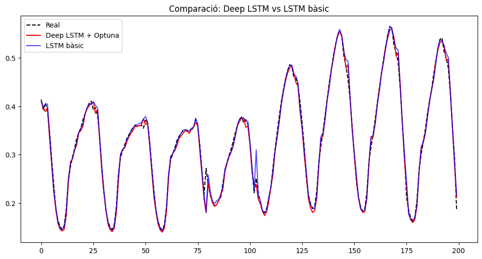

```python
# Avaluar el model profund
deep_lstm_mse = mean_squared_error(y_test, model_deep_lstm.predict(X_test))
print(f"MSE (Deep LSTM + Optuna): {deep_lstm_mse:.6f}")

# Comparar amb models anteriors (exercici 5)
print("Comparació de MSE:")
print(f"- RNN: {mean_squared_error(y_test, model_rnn.predict(X_test)):.6f}")
print(f"- GRU: {mean_squared_error(y_test, model_gru.predict(X_test)):.6f}")
print(f"- LSTM bàsic: {mean_squared_error(y_test, model_lstm.predict(X_test)):.6f}")
print(f"- LSTM profund + Optuna: {deep_lstm_mse:.6f}")

# Gràfica comparativa de prediccions (primeres 200 mostres)
plt.figure(figsize=(12, 6))
plt.plot(y_test[:200], label='Real', color='black', linestyle='--')
plt.plot(model_deep_lstm.predict(X_test[:200]), label='Deep LSTM + Optuna', color='red')
plt.plot(model_lstm.predict(X_test[:200]), label='LSTM bàsic', color='blue', alpha=0.7)
plt.legend()
plt.title("Comparació: Deep LSTM vs LSTM bàsic")
plt.show()
```